# Next word prediction

Masaru Nakajima

2023-03-02

# Next word prediction project

This project is for the Data Science Capstone course by Coursera.  
The data was provided by Coursera.

## Basic summary of the data

The data were three text files containing texts from three different sources.

- Twitter
- Blogs
- News

Data size summary

| file | lines | size_MB |
| --- | --- | --- |
| twitter | 2360148 | 160 |
| blogs | 899288 | 201 |
| news | 1010242 | 197 |
| Total | 4269678 | 558 |

## Ngram model for next-word prediction

I used the `sbo` package in R, which is the implementation of [Stupid-Backoff](https://aclanthology.org/D07-1090/) model. I split the data into train (80%) and test (20%) datasets. I used n-gram model for n = 2, 3, 4, 5.

### Train dataset size vs Accuracy

The folloiwng plot shows the  
relationship between the amount of data from the train dataset used for  
training and the accuracy of the model, for each value of n. We see that the  
performance increases as n increases. Also, the accuracy increases as the  
train data increases, which makes sense. However, even if we use all the  
train data, the highest accuracy possible is about 0.5.

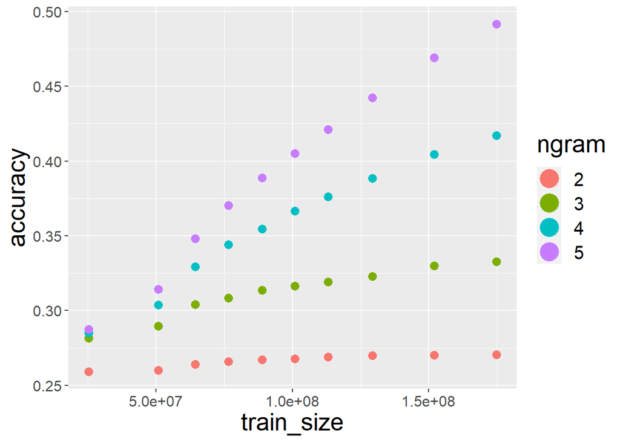

### Train dataset size vs evaluation time and predictor size

The below figures show the result.

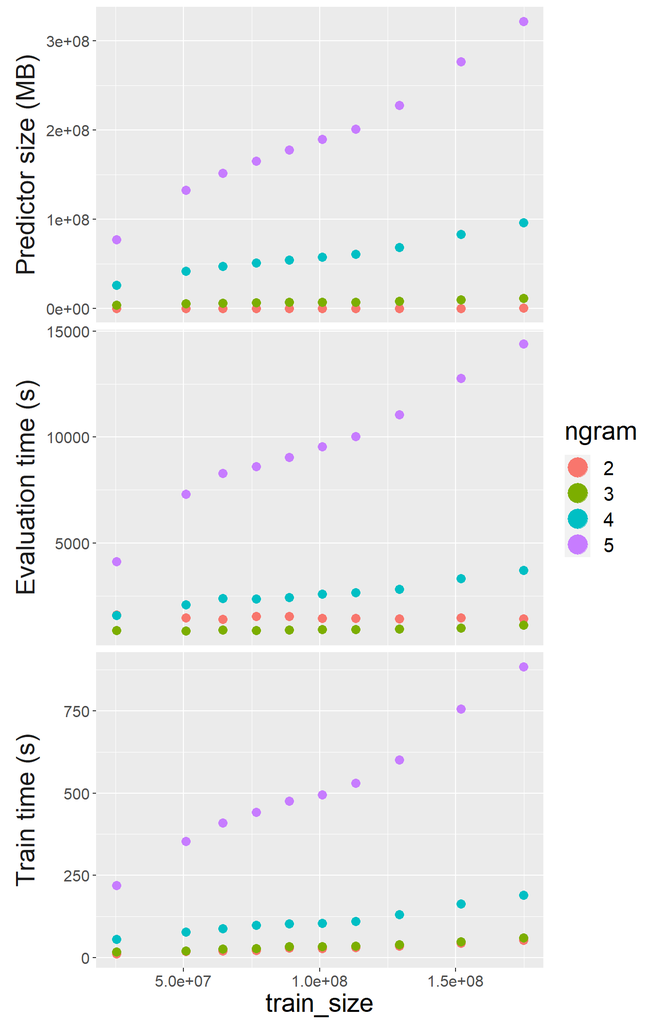

## Shiny App Product

I published a shiny app using 4-gram model.

[interactive chart not shown]